# Time Series Assignment 1

Arindam Patra

03/11/2021

# Importing libraries

```r
knitr::opts_chunk$set(echo = TRUE, warning = FALSE, tidy = TRUE)
library(tseries)
library(forecast)
library(moments)
```

# Importing Data

**Monthly Electric Production data from 1985-2017**

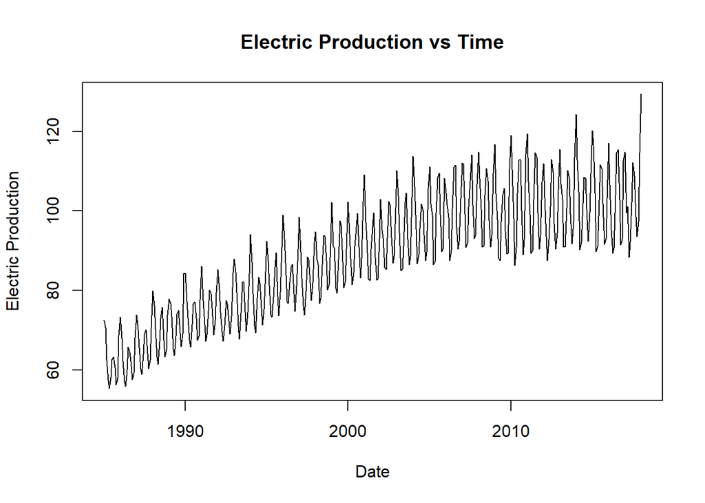

```r
df <- read.csv("time_series/Electric_Production.csv",row.names="DATE")
data = ts(df)
Time <- as.Date(rownames(df),'%m/%d/%Y')

plot(Time ,data, xlab = 'Date',ylab = 'Electric Production',
     main = 'Electric Production vs Time', type = 'l')
```

# Descriptive Statistics

```r
m = mean(data)
s = sd(data)
print(paste("Minimum = ", min(data)))
```

```
## [1] "Minimum =  55.3151"
```

```r
print(paste("Maximum = ", max(data)))
```

```
## [1] "Maximum =  129.4048"
```

```r
print(paste("Range = ", max(data) - min(data)))
```

```
## [1] "Range =  74.0897"
```

```r
print(paste("Mean = ", m))
```

```
## [1] "Mean =  88.8472176322418"
```

```r
print(paste("Standard deviation = ", s))
```

```
## [1] "Standard deviation =  15.3878336647309"
```

```r
print(paste("1st Quartile = ", quantile(data, 0.25)))
```

```
## [1] "1st Quartile =  77.1052"
```

```r
print(paste("2nd Quartile (Median) = ", quantile(data, 0.5)))
```

```
## [1] "2nd Quartile (Median) =  89.7795"
```

```r
print(paste("3rd Quartile = ", quantile(data, 0.75)))
```

```
## [1] "3rd Quartile =  100.5244"
```

```r
print(paste("Inter quartile range = ", IQR(data)))
```

```
## [1] "Inter quartile range =  23.4192"
```

```r
print(paste("Skewness = ", skewness(data)))
```

```
## [1] "Skewness =  -0.0728191541455781"
```

```r
print(paste("Kurtosis = ", kurtosis(data)))
```

```
## [1] "Kurtosis =  2.2994360495705"
```

```r
x = round(((length(data[data > m - (3 * s) & data < m + (3 * s)]) * 100)/length(data)),
          3)
print(paste("Percentage of observations in 3-sigma deviation of the mean = ", x, "%"))
```

```
## [1] "Percentage of observations in 3-sigma deviation of the mean =  100 %"
```

**Since all the data lies between 3 SD, so the data doesn’t have any outlier.**

# Stationarity Test

**Let’s test the stationarity of this time series. We will test it using 3 tests - ADF, KPSS and PP Test.**

```r
adf = adf.test(data)
adf
```

```
##
##  Augmented Dickey-Fuller Test
##
## data:  data
## Dickey-Fuller = -5.139, Lag order = 7, p-value = 0.01
## alternative hypothesis: stationary
```

```r
kpss = kpss.test(data)
kpss
```

```
##
##  KPSS Test for Level Stationarity
##
## data:  data
## KPSS Level = 6.3058, Truncation lag parameter = 5, p-value = 0.01
```

```r
pp = PP.test(data)
pp
```

```
##
##  Phillips-Perron Unit Root Test
##
## data:  data
## Dickey-Fuller = -8.2573, Truncation lag parameter = 5, p-value = 0.01
```

**Here ADF and PP test are agreed for stationarity of this data but KPSS is saying non-stationary. So let’s do the first difference of the data.**

# First Difference

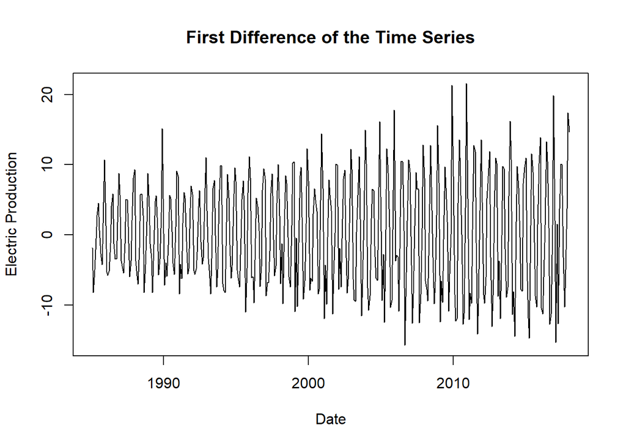

```r
first_diff <- diff(data)
plot(Time[-1],first_diff, xlab = 'Date',ylab = 'Electric Production',
     main = 'First Difference of the Time Series',type = 'l')
```

```r
adf = adf.test(first_diff)
adf
```

```
##
##  Augmented Dickey-Fuller Test
##
## data:  first_diff
## Dickey-Fuller = -9.6447, Lag order = 7, p-value = 0.01
## alternative hypothesis: stationary
```

```r
kpss = kpss.test(first_diff)
kpss
```

```
##
##  KPSS Test for Level Stationarity
##
## data:  first_diff
## KPSS Level = 0.078012, Truncation lag parameter = 5, p-value = 0.1
```

```r
pp = PP.test(first_diff)
pp
```

```
##
##  Phillips-Perron Unit Root Test
##
## data:  first_diff
## Dickey-Fuller = -15.573, Truncation lag parameter = 5, p-value = 0.01
```

**Ok! Here all of them agrees with the stationarity of this time series data. Therefore we can fit this data to our model.**

# Train test split

**Keeping last 20 observations as test data and rest of them as train data.**

```r
test_size <- 20
n <- length(first_diff)
train_size <- n - test_size

train_data <- first_diff[c(1 : train_size)]
test_data <- first_diff[c((train_size+1) : n)]
```

```r
### Total data points
length(first_diff)
```

```
## [1] 396
```

```r
### Training Data Size
length(train_data)
```

```
## [1] 376
```

```r
### Test Data Size
length(test_data)
```

```
## [1] 20
```

# Modelling

**At first we will build two optimized model. 1 - Using AIC, 2 - Using BIC**

### Using AIC

```r
aic_model <- auto.arima(train_data, trace= TRUE,d= 0, max.p = 10, max.q = 10,
                        ic ="aic", approximation = FALSE)
```

```
##
##  ARIMA(2,0,2) with non-zero mean : 2082.145
##  ARIMA(0,0,0) with non-zero mean : 2593.348
##  ARIMA(1,0,0) with non-zero mean : 2536.677
##  ARIMA(0,0,1) with non-zero mean : 2470.228
##  ARIMA(0,0,0) with zero mean     : 2591.363
##  ARIMA(1,0,2) with non-zero mean : 2345.833
##  ARIMA(2,0,1) with non-zero mean : 2089.945
##  ARIMA(3,0,2) with non-zero mean : 2076.4
##  ARIMA(3,0,1) with non-zero mean : 2076.408
##  ARIMA(4,0,2) with non-zero mean : 2064.957
##  ARIMA(4,0,1) with non-zero mean : 2071.16
##  ARIMA(5,0,2) with non-zero mean : 2049.122
##  ARIMA(5,0,1) with non-zero mean : 2072.437
##  ARIMA(6,0,2) with non-zero mean : Inf
##  ARIMA(5,0,3) with non-zero mean : Inf
##  ARIMA(4,0,3) with non-zero mean : Inf
##  ARIMA(6,0,1) with non-zero mean : 2072.464
##  ARIMA(6,0,3) with non-zero mean : Inf
##  ARIMA(5,0,2) with zero mean     : 2060.629
##
##  Best model: ARIMA(5,0,2) with non-zero mean
```

```r
aic_model
```

```
## Series: train_data
## ARIMA(5,0,2) with non-zero mean
##
## Coefficients:
##          ar1      ar2      ar3      ar4     ar5      ma1      ma2    mean
##       0.6928  -0.3857  -0.2180  -0.0489  0.2877  -0.8282  -0.0991  0.1095
## s.e.  0.1446   0.1248   0.0998   0.0734  0.0573   0.1451   0.1311  0.0208
##
## sigma^2 estimated as 13.12:  log likelihood=-1015.56
## AIC=2049.12   AICc=2049.61   BIC=2084.49
```

**For AIC, Best model is ARMA(5,2).**

### Using BIC

```r
bic_model <- auto.arima(train_data, trace= TRUE,d=0, max.p = 10, max.q = 10,
                        ic ="bic", approximation = FALSE)
```

```
##
##  ARIMA(2,0,2) with non-zero mean : 2105.723
##  ARIMA(0,0,0) with non-zero mean : 2601.207
##  ARIMA(1,0,0) with non-zero mean : 2548.466
##  ARIMA(0,0,1) with non-zero mean : 2482.016
##  ARIMA(0,0,0) with zero mean     : 2595.293
##  ARIMA(1,0,2) with non-zero mean : 2365.481
##  ARIMA(2,0,1) with non-zero mean : 2109.593
##  ARIMA(3,0,2) with non-zero mean : 2103.907
##  ARIMA(3,0,1) with non-zero mean : 2099.985
##  ARIMA(3,0,0) with non-zero mean : 2166.644
##  ARIMA(4,0,1) with non-zero mean : 2098.667
##  ARIMA(4,0,0) with non-zero mean : 2093.737
##  ARIMA(5,0,0) with non-zero mean : 2098.297
##  ARIMA(5,0,1) with non-zero mean : 2103.874
##  ARIMA(4,0,0) with zero mean     : 2089.178
##  ARIMA(3,0,0) with zero mean     : 2161.152
##  ARIMA(5,0,0) with zero mean     : 2093.927
##  ARIMA(4,0,1) with zero mean     : 2094.259
##  ARIMA(3,0,1) with zero mean     : 2102.707
##  ARIMA(5,0,1) with zero mean     : 2099.486
##
##  Best model: ARIMA(4,0,0) with zero mean
```

```r
bic_model
```

```
## Series: train_data
## ARIMA(4,0,0) with zero mean
##
## Coefficients:
##           ar1      ar2      ar3      ar4
##       -0.0231  -0.4336  -0.4910  -0.4355
## s.e.   0.0466   0.0390   0.0388   0.0467
##
## sigma^2 estimated as 14.03:  log likelihood=-1029.76
## AIC=2069.53   AICc=2069.69   BIC=2089.18
```

**For BIC, Best model is ARMA(4,0).**

# Choosing BEST Model

**We will check MSE for both of these models. For whichever model the MSE is lowest, we will choose that.**

```r
pred_aic<- forecast(aic_model, h = 20)
aic_forecast<- pred_aic$mean
mse_aic = sum((test_data - aic_forecast)^2)/length(test_data)
print(paste("MSE for AIC Model = ", mse_aic))
```

```
## [1] "MSE for AIC Model =  37.4904858003665"
```

```r
pred_bic <- forecast(bic_model, h = 20)
bic_forecast<- pred_bic$mean
mse_bic = sum((test_data - bic_forecast)^2)/length(test_data)
print(paste("MSE for BIC Model = ", mse_bic))
```

```
## [1] "MSE for BIC Model =  38.2007743700181"
```

**As we can see, MSE for AIC model is lowest. So we will choose that.** **Therefore ARMA(5,2) is the best model and we will forecast with respect to this model.**

# Residuals

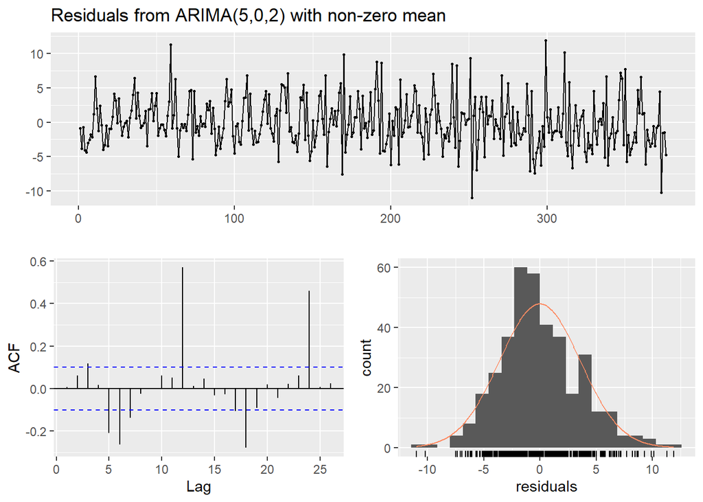

```
##
##  Ljung-Box test
##
## data:  Residuals from ARIMA(5,0,2) with non-zero mean
## Q* = 60.265, df = 3, p-value = 5.159e-13
##
## Model df: 8.   Total lags used: 11
```

```r
checkresiduals(aic_model)
```

**We can see that residual follows almost a normal distribution which is a good sign for this model.**

# Forecasting

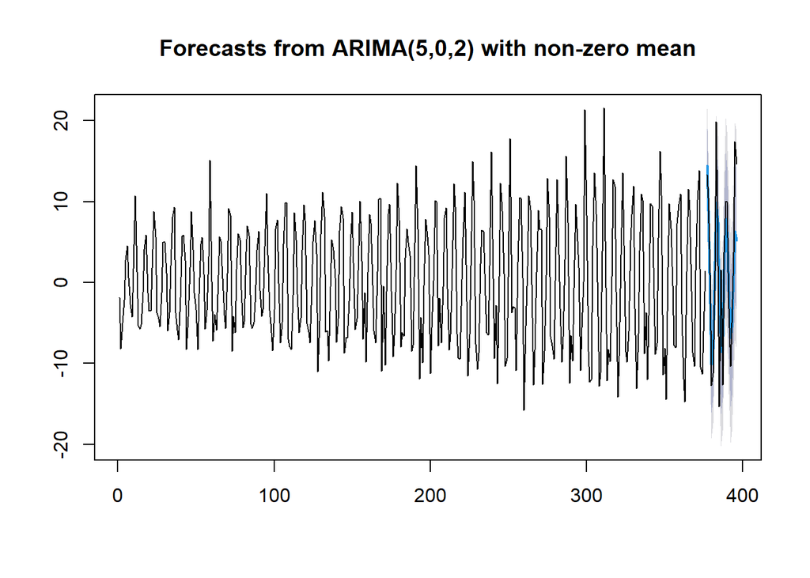

```r
plot(forecast(aic_model,h=20),type='l')
lines(c((train_size+1):n),test_data, col = 'black')
```

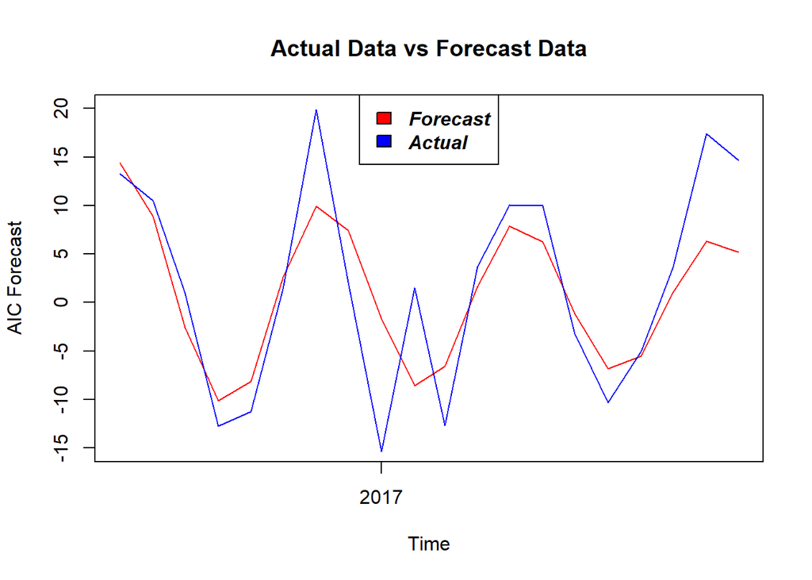

```r
plot(Time[(train_size  +1): n],aic_forecast,type='l',col = 'red',
     ylim = c(-15,20),xlab = 'Time',ylab = 'AIC Forecast',
     main = 'Actual Data vs Forecast Data')

lines(Time[(train_size+1):n],test_data, col = 'blue')
legend('top', legend=c("Forecast", "Actual"),fill=c("red", "blue"), text.font=4)
```

# Inverse Transformation

```r
y_hat = rep(0, (length(test_data) + 1))
y_hat[1] = data[(length(train_data))]
for (i in 2:(length(test_data) + 1)) {
  y_hat[i] = aic_forecast[i - 1] +  y_hat[i - 1]
}

df_compare = data.frame(cbind(y_hat[2:(length(test_data) + 1)], data[c((train_size+2) : length(Time))]))
## Took (train_size + 2), since in the main data we have one extra row, first one.
colnames(df_compare) = c("Predicted", "Actual")
df_compare
```

```
##    Predicted   Actual
## 1  103.76434 104.0375
## 2  112.64052 114.5397
## 3  110.02710 115.5159
## 4   99.91560 102.7637
## 5   91.75646  91.4867
## 6   94.36664  92.8900
## 7  104.28110 112.7694
## 8  111.73824 114.8505
## 9  110.07556  99.4901
## 10 101.48482 101.0396
## 11  94.88823  88.3530
## 12  96.55488  92.0805
## 13 104.42672 102.1532
## 14 110.69114 112.1538
## 15 109.55664 108.9312
## 16 102.73284  98.6154
## 17  97.24516  93.6137
## 18  98.35416  97.3359
## 19 104.65782 114.7212
## 20 109.87463 129.4048
```

**Now let’s plot it.**

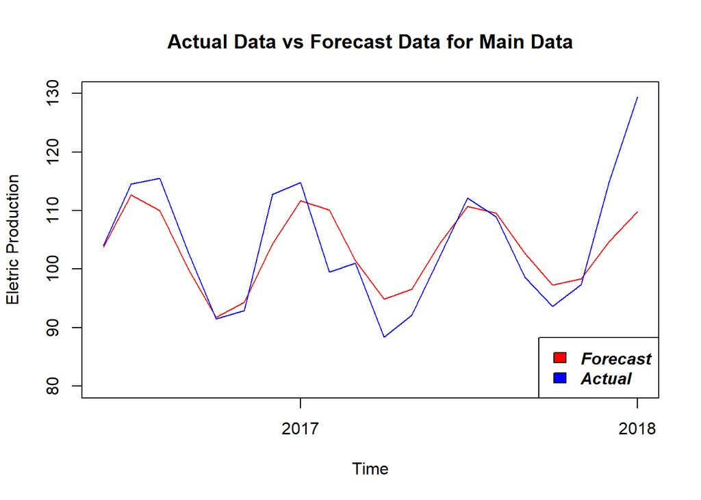

```r
plot(Time[(train_size+2):length(Time)],df_compare$Predicted,type='l',col = 'red', ylim = c(80,130),
     ylab = 'Eletric Production',xlab ='Time',
     main = 'Actual Data vs Forecast Data for Main Data')

lines(Time[(train_size+2):length(Time)],df_compare$Actual, col = 'blue')
legend('bottomright', legend=c("Forecast", "Actual"),fill = c("red", "blue"), text.font=4)
```